# Data Wrangling Project

## 1. Gathering the Data

We have to use twitter API to download information about tweets. We use also csv files.

## 2. Assesing the data

In order to assess data, we look at dataframes visually and programmatically to evaluate datatypes and to notice missing values.

## 3. Cleaning the data

### Defining things to clean and correct:

- the following columns: timestamp, retweeted_status_timestamp data types should be datatime instead of object type.
- the following columns in_reply_to_status_id and in_reply_to_user_id should be defined as integers, not as floats
- the rating_denominator column should be always 10. For some rows this value is different than 10.
- the name column has missing values, some names are not correct
- we have to remove unnecessary columns.'in_reply_to_status_id', 'in_reply_to_user_id'

### Quality issues

**twitter_df dataframe - things to correct**:

**Quality Issues**

- the following columns: timestamp, retweeted_status_timestamp data types should be datatime instead of object type.
- the following columns in_reply_to_status_id and in_reply_to_user_id should be defined as integers, not as floats
- the rating_denominator column should be always 10. For some rows this value is different than 10.
- the name column has missing values, some names are not correct
- Changing dogs breeds names to lower letters in the doggo_pred_df dataframe
- Changing the tweet_id column datatype to integer for all dataframes in order to perform a successful merge
- Extracting the gender of a dog out of a tweet
- we have to remove unnecessary columns: 'in_reply_to_status_id', 'in_reply_to_user_id'
- Dropping duplicated urls in the twitter_df_clean dateframe
- Dropping duplicated jpg urls in the doggo_pred_df dateframe  
  **Tidiness Issues**
- combining 3 dataframes to create one master/main dataframe
- merging four dog_stages columns into a single one

### Visualisation 1

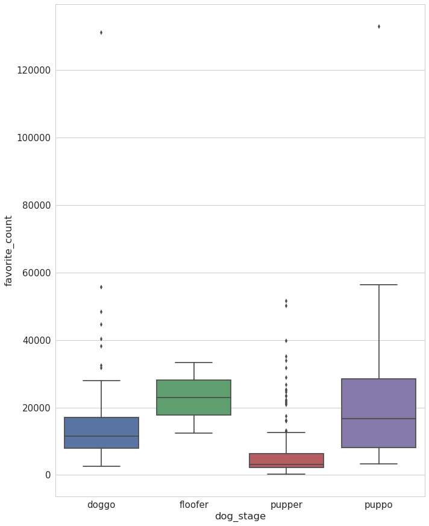

```python
sns.boxplot(data=main_df, x='dog_stage', y='favorite_count')
```

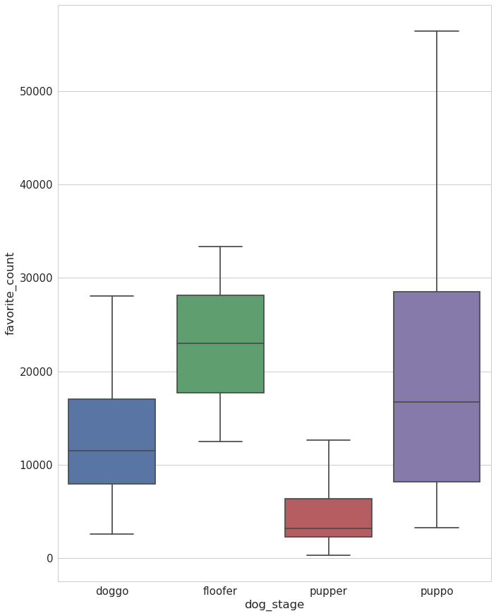

```python
sns.boxplot(data=main_df, x='dog_stage', y='favorite_count', showfliers=False)
```

### Comment

It is important to notice that the sample of floofer breed is very small (only 3 dogs of this breed). It cannot be considered as a representative sample. Puppo has much larger the maximum favorite count. On the other hand, pupper has much smaller maximum favorite count

### Visualisation 2

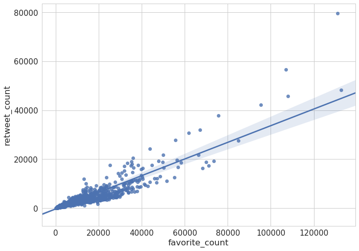

```python
ax = sns.regplot(x="favorite_count", y="retweet_count", data=main_df)
```

### Comment

On the scatter plot, one can notice strong postive correlation between favorite count and retrieve count, which was expected.

### Visualisation 3

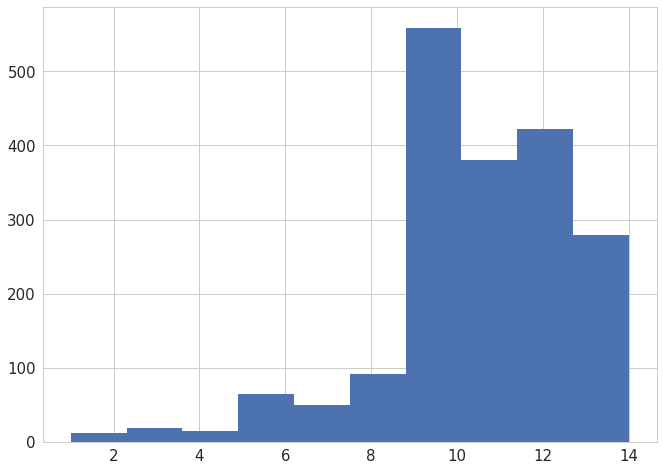

```python
plt.hist( x=main_df.rating_numerator)
```

### Comment

The distribution of ratings is left-skewed, which means that people evaluated dogs mostly in a positive way.